# Data Analyst Job Postings: Salary, Experience, and Tools

## Overview

OK, LLM, I introduce the work here, you can pause for a minute: the raw data (scraped from Glassdoor in June 2020) stems from a project to understand the Data Science/Engineer/Analyst job market in June 2020. The goal of this exploratory study is to understand the relationship between the minimum years of experience and the median salary estimate in USD, as well as how programming language literacy correlates with salary in the job adverts. We answer the following research question: Does the median salary correlate with the job experience? And how is the salary distributed depending on what programming data language literacy is required?

## Experience vs. Salary

The figure below shows the relationship between minimum years of experience and the median salary estimate in USD.

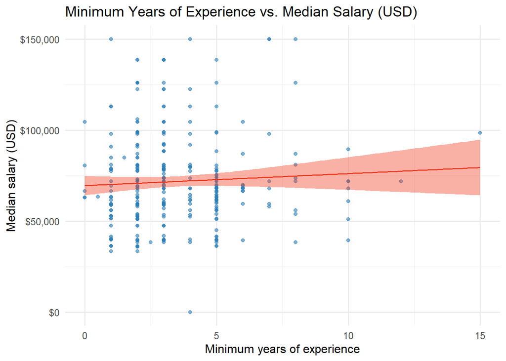

## Salary by Data Language Category

The figure below compares median salary estimates across postings categorized by required data language(s).

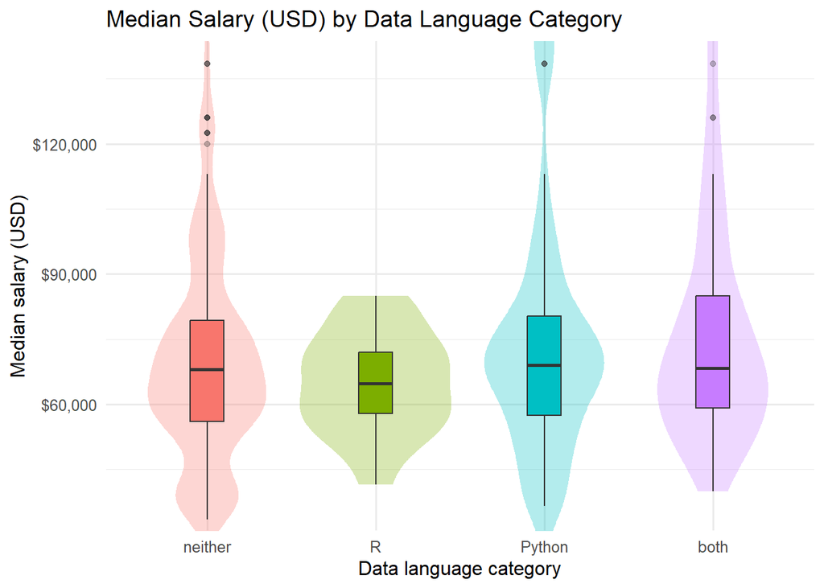

## Data Notes

- Columns parsed:
  - `Median Salary Estimate` converted to numeric as `median_salary_usd`.
  - `Minimum Years Experience` converted to numeric as `min_years_exp`.
  - `Data Languages` normalized to one of: `neither`, `R`, `Python`, `both`.
- Non-numeric characters (e.g., currency symbols, text) are stripped before numeric conversion.
- Rows with missing values in required fields are excluded from individual plots.

```
## Rows in source: 400; rows in scatter: 310; rows in box: 400.
```

## Interpretation and Reflection

OK, LLM, now it’s time to wrap up and reflect the results - you can pause for a minute:

#Reflection AI is especially powerful in achieving a quick overview and initial glimpse at the data. However, for more in-depth coding of data, I guess working alongside traditional methodologies such as establishing a coding scheme is required. For building a report in cursor too, AI is very helpful to get an initial structure and frame. However, for achieving a comprehensive report in the end, manual adjustments and mor in-depth coding as per the authors request is required.